# Global Youtube Statistics 2023

Sravani Neelapala

2023-09-05

## R Markdown

```r
library(tidyverse)
library(dplyr)
```

Introduction: When I was checking all the open sources for the datasets to analyze, I came across this ‘Global YouTube Statistics 2023’ from the Kaggle website.This dataset give information of top 1000 Youtubers around the world, which is a recent one to find information and a familiar domain for me as well as for anyone to understand. I felt this dataset is interesting because we can checkout the top 1000 Youtubers around the world and I felt I can attain a good knowledge from this dataset.By checking the comprehensive details of the top creators by their subscriber count, video views, upload frequency, country of origin,earnings and more.I want to analyze the position of the YouTube channel based on applying various columns from the datset like subscriber, video views, etc. Analyzing all this information could give a better understanding of people who aspire to become online content creators on YouTube.

** Citation: https://www.kaggle.com/datasets/nelgiriyewithana/global-youtube-statistics-2023 **

Data Collection: I collected data from one of the open sources given, namely the Kaggle website.I came across a ‘global YouTube Statistics 2023’ data set and felt that it could be a familiar domain for me as well as for everyone to understand.

Cases: The rows describe the top 1000 YouTubers from around the world who are online content creators.

Variables: There are a total of 28 variables in the dataset. Out of this 28, I would like to focus more on subscribers, video views, category, uploads, country, earnings and channel rank,etc.

Type of Study: The study is experimental because we convert certain numerical columns into categorical variables for better analysis. Additionally, we intent to remove columns that do not significantly contribute to extracting meaningful information from the data,as they merely duplicate information from other columns.

```r
indata <- read.csv("/Users/Sravani/Desktop/Sravani DOCS/FALL 2023/ISE 201/Sravani- SJSU - 201/Global YouTube Statistics.csv")

# Check if data import was as expected
dim(indata)
```

```
## [1] 995  28
```

```r
head(indata)
```

```
##   rank                   Youtuber subscribers  video.views         category
## 1    1                   T-Series   245000000 228000000000            Music
## 2    2             YouTube Movies   170000000            0 Film & Animation
## 3    3                    MrBeast   166000000  28368841870    Entertainment
## 4    4 Cocomelon - Nursery Rhymes   162000000 164000000000        Education
## 5    5                  SET India   159000000 148000000000            Shows
## 6    6                      Music   119000000            0              nan
##                        Title uploads       Country Abbreviation  channel_type
## 1                   T-Series   20082         India           IN         Music
## 2              youtubemovies       1 United States           US         Games
## 3                    MrBeast     741 United States           US Entertainment
## 4 Cocomelon - Nursery Rhymes     966 United States           US     Education
## 5                  SET India  116536         India           IN Entertainment
## 6                      Music       0           nan          nan         Music
##   video_views_rank country_rank channel_type_rank
```

[output cut: 41 more lines]

** This data has 995 observations and 28 variables,but it seems like it is not yet in the tidy format.**

```r
#Is it a data frame?
is.data.frame(indata)
```

```
## [1] TRUE
```

** It checks whether the input data is a data frame or not. **

```r
# data is in tibble format or not
indata <- as_tibble(indata)
is_tibble(indata)
```

```
## [1] TRUE
```

** The ‘indata’ is in a data frame, and want to convert it into a tibble.**

```r
#Summary of data
summary(indata)
```

```
##       rank         Youtuber          subscribers         video.views
##  Min.   :  1.0   Length:995         Min.   : 12300000   Min.   :0.000e+00
##  1st Qu.:249.5   Class :character   1st Qu.: 14500000   1st Qu.:4.288e+09
##  Median :498.0   Mode  :character   Median : 17700000   Median :7.761e+09
##  Mean   :498.0                      Mean   : 22982412   Mean   :1.104e+10
##  3rd Qu.:746.5                      3rd Qu.: 24600000   3rd Qu.:1.355e+10
##  Max.   :995.0                      Max.   :245000000   Max.   :2.280e+11
##
##    category            Title              uploads           Country
##  Length:995         Length:995         Min.   :     0.0   Length:995
##  Class :character   Class :character   1st Qu.:   194.5   Class :character
##  Mode  :character   Mode  :character   Median :   729.0   Mode  :character
##                                        Mean   :  9187.1
##                                        3rd Qu.:  2667.5
##                                        Max.   :301308.0
##
##  Abbreviation       channel_type       video_views_rank   country_rank
##  Length:995         Length:995         Min.   :      1   Min.   :   1.0
##  Class :character   Class :character   1st Qu.:    323   1st Qu.:  11.0
##  Mode  :character   Mode  :character   Median :    916   Median :  51.0
##                                        Mean   : 554249   Mean   : 386.1
##                                        3rd Qu.:   3584   3rd Qu.: 123.0
##                                        Max.   :4057944   Max.   :7741.0
##                                        NA's   :1         NA's   :116
##  channel_type_rank video_views_for_the_last_30_days lowest_monthly_earnings
##  Min.   :   1.0    Min.   :1.000e+00                Min.   :     0
##  1st Qu.:  27.0    1st Qu.:2.014e+07                1st Qu.:  2700
##  Median :  65.5    Median :6.408e+07                Median : 13300
##  Mean   : 745.7    Mean   :1.756e+08                Mean   : 36886
##  3rd Qu.: 139.8    3rd Qu.:1.688e+08                3rd Qu.: 37900
##  Max.   :7741.0    Max.   :6.589e+09                Max.   :850900
##  NA's   :33        NA's   :56
##  highest_monthly_earnings lowest_yearly_earnings highest_yearly_earnings
##  Min.   :       0         Min.   :       0       Min.   :        0
##  1st Qu.:   43500         1st Qu.:   32650       1st Qu.:   521750
##  Median :  212700         Median :  159500       Median :  2600000
##  Mean   :  589808         Mean   :  442257       Mean   :  7081814
##  3rd Qu.:  606800         3rd Qu.:  455100       3rd Qu.:  7300000
##  Max.   :13600000         Max.   :10200000       Max.   :163400000
##
```

[output cut: 9 more lines]

```
##  Min.   :  7.60                          Min.   :2.025e+05   Min.   : 0.750
##  1st Qu.: 36.30                          1st Qu.:8.336e+07   1st Qu.: 5.270
##  Median : 68.00                          Median :3.282e+08   Median : 9.365
##  Mean   : 63.63                          Mean   :4.304e+08   Mean   : 9.279
##  3rd Qu.: 88.20                          3rd Qu.:3.282e+08   3rd Qu.:14.700
##  Max.   :113.10                          Max.   :1.398e+09   Max.   :14.720
##  NA's   :123                             NA's   :123         NA's   :123
##  Urban_population       Latitude        Longitude
##  Min.   :    35588   Min.   :-38.42   Min.   :-172.10
##  1st Qu.: 55908316   1st Qu.: 20.59   1st Qu.: -95.71
##  Median :270663028   Median : 37.09   Median : -51.93
##  Mean   :224214982   Mean   : 26.63   Mean   : -14.13
##  3rd Qu.:270663028   3rd Qu.: 37.09   3rd Qu.:  78.96
##  Max.   :842933962   Max.   : 61.92   Max.   : 138.25
##  NA's   :123         NA's   :123      NA's   :123
```

** Summary of the ‘indata’ dataset, comprising 28 variables of numerical, ordinal, continuous nature, featuring the mean, median, and interquartile range (IQR). This summary will be helpful for graph plotting. **

```r
# Convert Country into a factor
indata$Country <- as.factor(indata$Country)

summary(indata$Country)
```

```
##          Afghanistan              Andorra            Argentina
##                    1                    1                   13
##            Australia           Bangladesh             Barbados
##                    9                    1                    1
##               Brazil               Canada                Chile
##                   62                   15                    3
##                China             Colombia                 Cuba
##                    1                   11                    1
##              Ecuador                Egypt          El Salvador
##                    2                    2                    1
##              Finland               France              Germany
##                    1                    5                    6
##                India            Indonesia                 Iraq
##                  168                   28                    2
##                Italy                Japan               Jordan
##                    2                    5                    3
##               Kuwait               Latvia             Malaysia
##                    1                    1                    1
##               Mexico              Morocco                  nan
##                   33                    1                  122
##          Netherlands             Pakistan                 Peru
##                    3                    6                    1
##          Philippines               Russia                Samoa
##                   12                   16                    1
##         Saudi Arabia            Singapore          South Korea
##                    9                    3                   17
##                Spain               Sweden          Switzerland
##                   22                    4                    1
##             Thailand               Turkey              Ukraine
##                   18                    4                    8
## United Arab Emirates       United Kingdom        United States
##                    7                   43                  313
##            Venezuela              Vietnam
##                    1                    3
```

```r
# Convert category into a factor
indata$category <- as.factor(indata$category)

summary(indata$category)
```

```
##      Autos & Vehicles                Comedy             Education
##                     2                    69                    45
##         Entertainment      Film & Animation                Gaming
##                   241                    46                    94
##         Howto & Style                Movies                 Music
##                    40                     2                   202
##                   nan       News & Politics Nonprofits & Activism
##                    46                    26                     2
##        People & Blogs        Pets & Animals  Science & Technology
##                   132                     4                    17
##                 Shows                Sports              Trailers
##                    13                    11                     2
##       Travel & Events
##                     1
```

```r
#Convert created_year into a factor
indata$created_year <- as.factor(indata$created_year)

summary(indata$created_year)
```

```
## 1970 2005 2006 2007 2008 2009 2010 2011 2012 2013 2014 2015 2016 2017 2018 2019
##    1   24   91   49   46   52   48   82   68   76   98   73   77   68   46   33
## 2020 2021 2022  NaN
##   30   23    5    5
```

```r
#Convert created_month into a factor
indata$created_month <- as.factor(indata$created_month)

summary(indata$created_month)
```

```
## Apr Aug Dec Feb Jan Jul Jun Mar May nan Nov Oct Sep
##  72  82  69  67 101  91  73  87  84   5  90  78  96
```

```r
#Remove extra columns
indata_cleaned <- select(indata, -(Abbreviation:channel_type))

head(indata_cleaned)
```

```
## # A tibble: 6 × 26
##    rank Youtuber          subscribers video.views category Title uploads Country
##   <int> <chr>                   <int>       <dbl> <fct>    <chr>   <int> <fct>
## 1     1 T-Series            245000000     2.28e11 Music    T-Se…   20082 India
## 2     2 YouTube Movies      170000000     0       Film & … yout…       1 United…
## 3     3 MrBeast             166000000     2.84e10 Enterta… MrBe…     741 United…
## 4     4 Cocomelon - Nurs…   162000000     1.64e11 Educati… Coco…     966 United…
## 5     5 SET India           159000000     1.48e11 Shows    SET …  116536 India
## 6     6 Music               119000000     0       nan      Music       0 nan
## # ℹ 18 more variables: video_views_rank <int>, country_rank <dbl>,
## #   channel_type_rank <dbl>, video_views_for_the_last_30_days <dbl>,
## #   lowest_monthly_earnings <dbl>, highest_monthly_earnings <dbl>,
## #   lowest_yearly_earnings <dbl>, highest_yearly_earnings <dbl>,
## #   subscribers_for_last_30_days <dbl>, created_year <fct>,
## #   created_month <fct>, created_date <dbl>,
## #   Gross.tertiary.education.enrollment.... <dbl>, Population <dbl>, …
```

** From 28 variables we are removing extra columns of Abbreviation,channel_type for better analysis **

```r
#checking for missing values
sum(is.na(indata))
```

```
## [1] 1286
```

** There are 1286 missing values in the data frame. **

```r
#checking for duplicate values
sum(duplicated(indata))
```

```
## [1] 0
```

** There are no duplicate values in the data frame. **

# SUMMARY STATISTICS

```r
# subscribers
mode <- function(x, na.rm = TRUE){
  which.max(tabulate(x))
}

indata %>%
  summarise(mean = mean(subscribers, na.rm = TRUE),
            median = median(subscribers,na.rm = TRUE),
            mode = mode(subscribers, na.rm = TRUE),
            var = var(subscribers, na.rm = TRUE),
            sd = sd(subscribers, na.rm = TRUE))
```

```
## # A tibble: 1 × 5
##        mean   median     mode     var        sd
##       <dbl>    <int>    <int>   <dbl>     <dbl>
## 1 22982412. 17700000 12500000 3.07e14 17526105.
```

```r
 max(indata$subscribers) - min(indata$subscribers)
```

```
## [1] 232700000
```

```r
# video.views
mode <- function(x, na.rm = TRUE){
  which.max(tabulate(x))
}

indata %>%
  summarise(mean = mean(video.views, na.rm = TRUE),
            median = median(video.views,na.rm = TRUE),
            mode = mode(video.views, na.rm = TRUE),
            var = var(video.views, na.rm = TRUE),
            sd = sd(video.views, na.rm = TRUE))
```

```
## # A tibble: 1 × 5
##           mean     median  mode     var           sd
##          <dbl>      <dbl> <int>   <dbl>        <dbl>
## 1 11039537052. 7760819588  2634 1.99e20 14110844377.
```

```r
 max(indata$video.views) - min(indata$video.views)
```

```
## [1] 2.28e+11
```

```r
 # uploads
mode <- function(x, na.rm = TRUE){
  which.max(tabulate(x))
}

indata %>%
  summarise(mean = mean(uploads, na.rm = TRUE),
            median = median(uploads,na.rm = TRUE),
            mode = mode(uploads, na.rm = TRUE),
            var = var(uploads, na.rm = TRUE),
            sd = sd(uploads, na.rm = TRUE))
```

```
## # A tibble: 1 × 5
##    mean median  mode         var     sd
##   <dbl>  <int> <int>       <dbl>  <dbl>
## 1 9187.    729     1 1166314861. 34151.
```

```r
 max(indata$uploads) - min(indata$uploads)
```

```
## [1] 301308
```

```r
mode <- function(x, na.rm = TRUE){
  which.max(tabulate(x))
}

indata %>%
  summarise(mean = mean(highest_yearly_earnings, na.rm = TRUE),
            median = median(highest_yearly_earnings,na.rm = TRUE),
            mode = mode(highest_yearly_earnings, na.rm = TRUE),
            var = var(highest_yearly_earnings, na.rm = TRUE),
            sd = sd(highest_yearly_earnings, na.rm = TRUE))
```

```
## # A tibble: 1 × 5
##       mean  median    mode     var        sd
##      <dbl>   <dbl>   <int>   <dbl>     <dbl>
## 1 7081814. 2600000 1300000 1.90e14 13797038.
```

```r
 max(indata$highest_yearly_earnings) - min(indata$highest_yearly_earnings)
```

```
## [1] 163400000
```

# VISUALIZATION

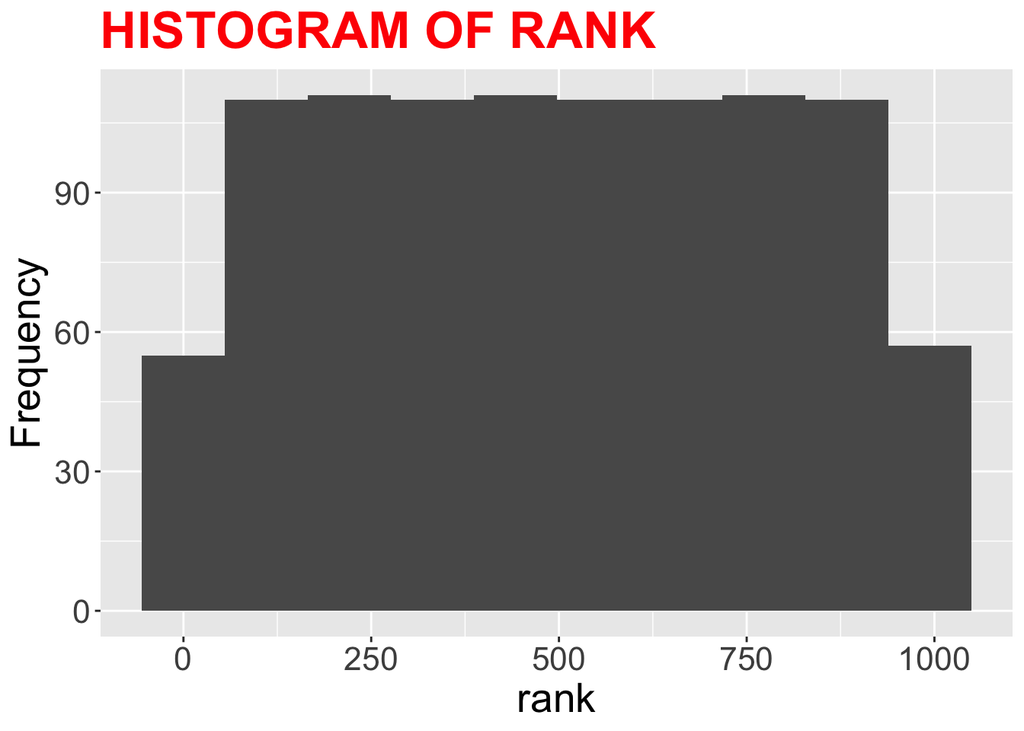

```r
# HISTOGRAM
ggplot(data = indata) +
   geom_histogram(mapping = aes(x =  rank), bins = 10) +
   labs(title = "HISTOGRAM OF RANK", x = "rank", y  = "Frequency") +
   theme(plot.title = element_text(color = "red", size = 25, face = "bold")) +
   theme(text = element_text(size = 20))
```

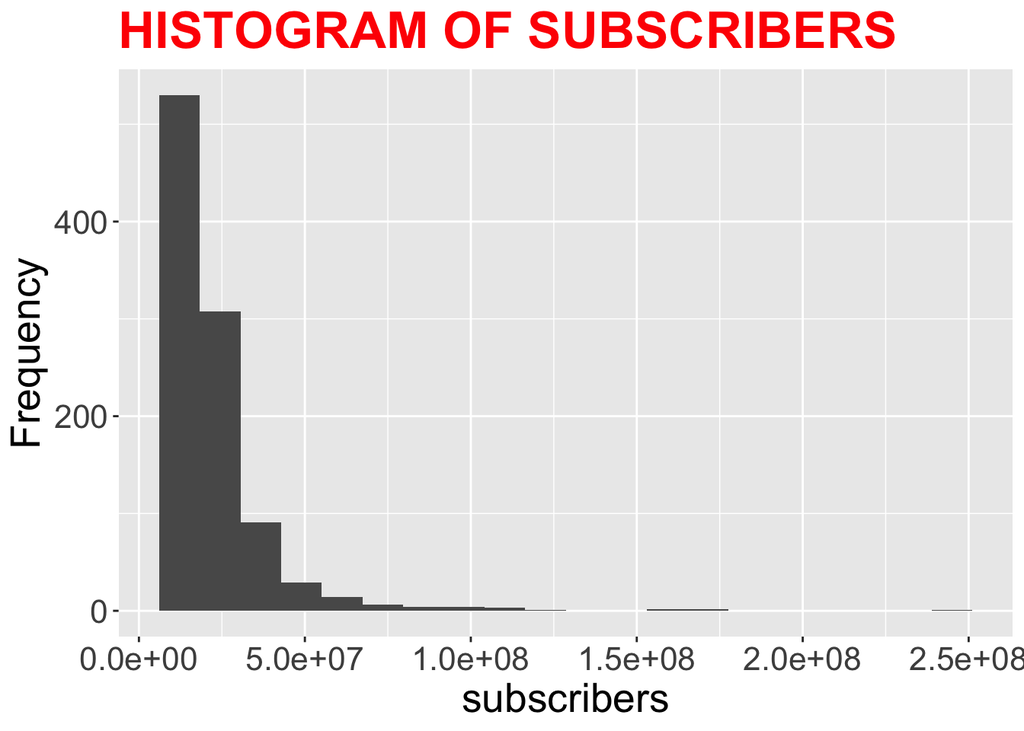

```r
# HISTOGRAM
ggplot(data = indata) +
   geom_histogram(mapping = aes(x = subscribers), bins = 20) +
   labs(title = "HISTOGRAM OF SUBSCRIBERS", x = "subscribers", y  = "Frequency") +
   theme(plot.title = element_text(color = "red", size = 25, face = "bold")) +
   theme(text = element_text(size = 20))
```

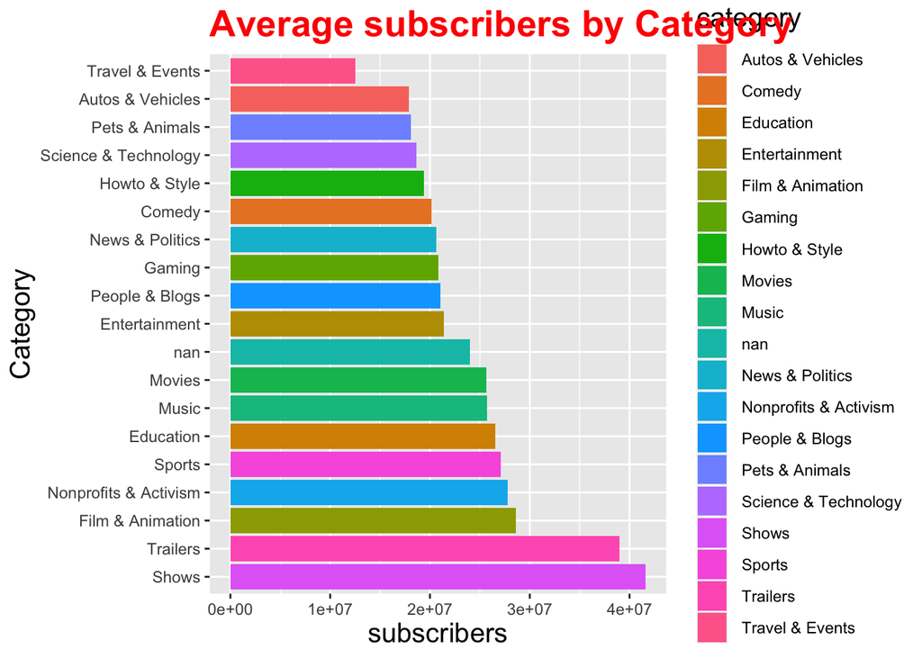

```r
# BAR CHART
indata %>%
  group_by(category) %>%
  summarise(Average = mean(subscribers)) %>%
  ggplot(aes(x = reorder(category, -Average), y = Average, fill = category)) +
  geom_bar(stat = "identity") +
  coord_flip() +
  labs(title = "Average subscribers by Category", x = "Category", y = "subscribers") +
  theme( plot.title = element_text(color = "red", size = 20, face = "bold")) +
  theme(title= element_text(size = 15))
```

** The distribution shows the average subscribers across different categories. You tubers from the Shows, Trailers category exhibit higher number of subscribers when compared to the mean of the subscribers. And the Travel & Events category have less subscribers when compared with mean of subscribers.**

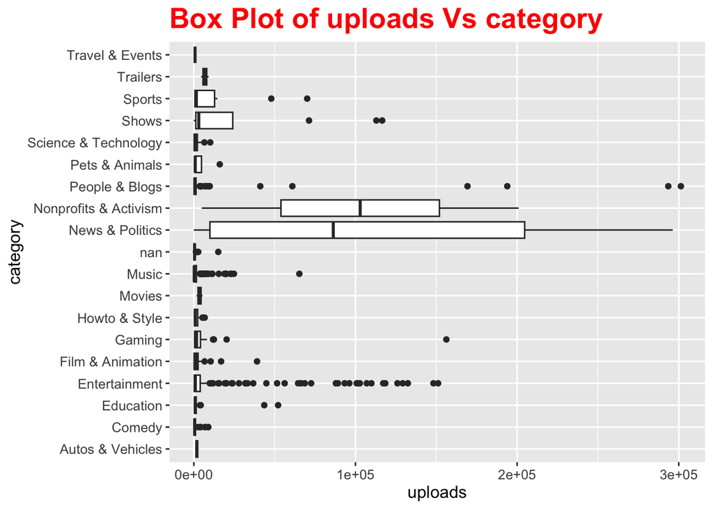

```r
# BOX PLOT
ggplot(data = indata, aes(x = category, y = uploads)) + geom_boxplot() + coord_flip() +
 labs(title = "Box Plot of uploads Vs category", x = "category", y = "uploads") +
theme( plot.title = element_text(color = "red", size = 20, face = "bold")) +
theme(text = element_text(size = 12))
```

** The uploads distribution across various categories. **

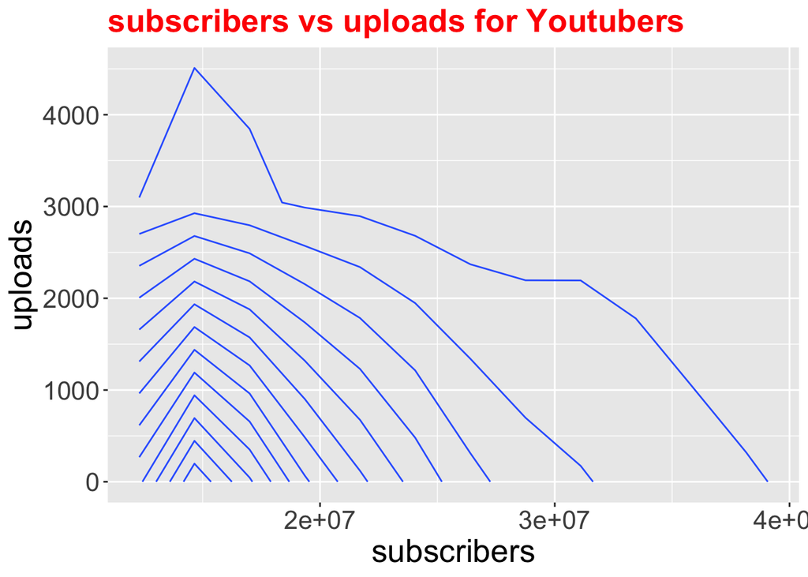

```r
# DENSITY PLOT
ggplot(data = indata, aes(x = subscribers, y = uploads)) +
  geom_density_2d() +
  labs(title = "subscribers vs uploads for Youtubers", x = "subscribers", y = "uploads") +
  theme(plot.title = element_text(color = "red", size = 20, face = "bold")) +
  theme(text = element_text(size = 20))
```

** This distribution shows how uploads are distributed among different subscriber groups of Youtubers. **